# Titanic Data EDA

## About the Data

Titanic passenger data.

The dataset contains information about passengers aboard the RMS Titanic, which sank on April 15, 1912, after colliding with an iceberg. The data includes attributes such as travel class, age, gender, number of siblings/spouses aboard, number of parents/children aboard, ticket fare, and port of embarkation.

The dataset also contains information on whether a passenger survived the disaster.

The Titanic carried over 2,200 people, of whom more than 1,500 died, making this disaster one of the most tragic in maritime history.

### Columns:

- **pclass** – Ticket class
- **survived** – Whether the passenger survived the disaster
- **name** – Passenger’s full name
- **sex** – Passenger’s gender
- **age** – Passenger’s age
- **sibsp** – Number of siblings/spouses aboard
- **parch** – Number of parents/children aboard
- **ticket** – Ticket number
- **fare** – Ticket fare
- **cabin** – Cabin number
- **embarked** – Port of embarkation (C = Cherbourg, Q = Queenstown, S = Southampton)
- **boat** – Lifeboat number
- **body** – Body identification number (if the passenger did not survive and the body was recovered)
- **home.dest** – Destination

The objective of this analysis is to investigate which factors may have influenced passenger survival during the RMS Titanic disaster, which occurred on April 15, 1912, after the ship collided with an iceberg.

The analysis is based on real-world data containing passenger information such as gender, age, ticket class, number of accompanying family members aboard, ticket fare, and port of embarkation.

During the analysis, various visualizations will be created to illustrate passenger distributions, demographic structure, and relationships between individual features and survival outcomes.

The goal of this analysis is not only to understand the overall profile of Titanic passengers, but above all to answer the question: who had the highest chances of survival, and which factors most significantly increased those chances.

```python
import pandas as pd
import seaborn as sns
import matplotlib.pyplot as plt
```

```python
df = pd.read_csv('26__titanic.csv', sep=",")
df
```

|  | pclass | survived | name | sex | age | sibsp | parch | ticket | fare | cabin | embarked | boat | body | home.dest |
| --- | --- | --- | --- | --- | --- | --- | --- | --- | --- | --- | --- | --- | --- | --- |
| 0 | 1.0 | 1.0 | Allen, Miss. Elisabeth Walton | female | 29.0000 | 0.0 | 0.0 | 24160 | 211.3375 | B5 | S | 2 | NaN | St Louis, MO |
| 1 | 1.0 | 1.0 | Allison, Master. Hudson Trevor | male | 0.9167 | 1.0 | 2.0 | 113781 | 151.5500 | C22 C26 | S | 11 | NaN | Montreal, PQ / Chesterville, ON |
| 2 | 1.0 | 0.0 | Allison, Miss. Helen Loraine | female | 2.0000 | 1.0 | 2.0 | 113781 | 151.5500 | C22 C26 | S | NaN | NaN | Montreal, PQ / Chesterville, ON |
| 3 | 1.0 | 0.0 | Allison, Mr. Hudson Joshua Creighton | male | 30.0000 | 1.0 | 2.0 | 113781 | 151.5500 | C22 C26 | S | NaN | 135.0 | Montreal, PQ / Chesterville, ON |
| 4 | 1.0 | 0.0 | Allison, Mrs. Hudson J C (Bessie Waldo Daniels) | female | 25.0000 | 1.0 | 2.0 | 113781 | 151.5500 | C22 C26 | S | NaN | NaN | Montreal, PQ / Chesterville, ON |
| ... | ... | ... | ... | ... | ... | ... | ... | ... | ... | ... | ... | ... | ... | ... |
| 1305 | 3.0 | 0.0 | Zabour, Miss. Thamine | female | NaN | 1.0 | 0.0 | 2665 | 14.4542 | NaN | C | NaN | NaN | NaN |
| 1306 | 3.0 | 0.0 | Zakarian, Mr. Mapriededer | male | 26.5000 | 0.0 | 0.0 | 2656 | 7.2250 | NaN | C | NaN | 304.0 | NaN |
| 1307 | 3.0 | 0.0 | Zakarian, Mr. Ortin | male | 27.0000 | 0.0 | 0.0 | 2670 | 7.2250 | NaN | C | NaN | NaN | NaN |
| 1308 | 3.0 | 0.0 | Zimmerman, Mr. Leo | male | 29.0000 | 0.0 | 0.0 | 315082 | 7.8750 | NaN | S | NaN | NaN | NaN |
| 1309 | NaN | NaN | NaN | NaN | NaN | NaN | NaN | NaN | NaN | NaN | NaN | NaN | NaN | NaN |

1310 rows × 14 columns

# 1.General overview of the dataset.

```python
# I examine the number of rows, data types, the presence of missing values (NaN), and the available columns.
df.sample(20)
```

|  | pclass | survived | name | sex | age | sibsp | parch | ticket | fare | cabin | embarked | boat | body | home.dest |
| --- | --- | --- | --- | --- | --- | --- | --- | --- | --- | --- | --- | --- | --- | --- |
| 1206 | 3.0 | 0.0 | Skoog, Master. Harald | male | 4.0 | 3.0 | 2.0 | 347088 | 27.9000 | NaN | S | NaN | NaN | NaN |
| 283 | 1.0 | 0.0 | Stewart, Mr. Albert A | male | NaN | 0.0 | 0.0 | PC 17605 | 27.7208 | NaN | C | NaN | NaN | Gallipolis, Ohio / ? Paris / New York |
| 981 | 3.0 | 1.0 | Lundstrom, Mr. Thure Edvin | male | 32.0 | 0.0 | 0.0 | 350403 | 7.5792 | NaN | S | 15 | NaN | NaN |
| 1013 | 3.0 | 0.0 | Meanwell, Miss. (Marion Ogden) | female | NaN | 0.0 | 0.0 | SOTON/O.Q. 392087 | 8.0500 | NaN | S | NaN | NaN | NaN |
| 108 | 1.0 | 1.0 | Fleming, Miss. Margaret | female | NaN | 0.0 | 0.0 | 17421 | 110.8833 | NaN | C | 4 | NaN | NaN |
| 249 | 1.0 | 1.0 | Ryerson, Master. John Borie | male | 13.0 | 2.0 | 2.0 | PC 17608 | 262.3750 | B57 B59 B63 B66 | C | 4 | NaN | Haverford, PA / Cooperstown, NY |
| 963 | 3.0 | 0.0 | Leonard, Mr. Lionel | male | 36.0 | 0.0 | 0.0 | LINE | 0.0000 | NaN | S | NaN | NaN | NaN |
| 456 | 2.0 | 0.0 | Howard, Mrs. Benjamin (Ellen Truelove Arman) | female | 60.0 | 1.0 | 0.0 | 24065 | 26.0000 | NaN | S | NaN | NaN | Swindon, England |
| 741 | 3.0 | 0.0 | Daher, Mr. Shedid | male | 22.5 | 0.0 | 0.0 | 2698 | 7.2250 | NaN | C | NaN | 9.0 | NaN |
| 241 | 1.0 | 0.0 | Rood, Mr. Hugh Roscoe | male | NaN | 0.0 | 0.0 | 113767 | 50.0000 | A32 | S | NaN | NaN | Seattle, WA |
| 1216 | 3.0 | 1.0 | Smyth, Miss. Julia | female | NaN | 0.0 | 0.0 | 335432 | 7.7333 | NaN | Q | 13 | NaN | NaN |
| 1172 | 3.0 | 0.0 | Sage, Miss. Ada | female | NaN | 8.0 | 2.0 | CA. 2343 | 69.5500 | NaN | S | NaN | NaN | NaN |
| 824 | 3.0 | 0.0 | Goncalves, Mr. Manuel Estanslas | male | 38.0 | 0.0 | 0.0 | SOTON/O.Q. 3101306 | 7.0500 | NaN | S | NaN | NaN | Portugal |
| 163 | 1.0 | 1.0 | Holverson, Mrs. Alexander Oskar (Mary Aline To... | female | 35.0 | 1.0 | 0.0 | 113789 | 52.0000 | NaN | S | 8 | NaN | New York, NY |
| 375 | 2.0 | 0.0 | Collander, Mr. Erik Gustaf | male | 28.0 | 0.0 | 0.0 | 248740 | 13.0000 | NaN | S | NaN | NaN | Helsinki, Finland Ashtabula, Ohio |
| 582 | 2.0 | 1.0 | Watt, Miss. Bertha J | female | 12.0 | 0.0 | 0.0 | C.A. 33595 | 15.7500 | NaN | S | 9 | NaN | Aberdeen / Portland, OR |
| 289 | 1.0 | 1.0 | Taussig, Miss. Ruth | female | 18.0 | 0.0 | 2.0 | 110413 | 79.6500 | E68 | S | 8 | NaN | New York, NY |
| 524 | 2.0 | 1.0 | Padro y Manent, Mr. Julian | male | NaN | 0.0 | 0.0 | SC/PARIS 2146 | 13.8625 | NaN | C | 9 | NaN | Spain / Havana, Cuba |
| 198 | 1.0 | 1.0 | Marvin, Mrs. Daniel Warner (Mary Graham Carmic... | female | 18.0 | 1.0 | 0.0 | 113773 | 53.1000 | D30 | S | 10 | NaN | New York, NY |
| 999 | 3.0 | 1.0 | McCarthy, Miss. Catherine "Katie" | female | NaN | 0.0 | 0.0 | 383123 | 7.7500 | NaN | Q | 15 16 | NaN | NaN |

```python
df.info()
```

```
<class 'pandas.core.frame.DataFrame'>
RangeIndex: 1310 entries, 0 to 1309
Data columns (total 14 columns):
 #   Column     Non-Null Count  Dtype
---  ------     --------------  -----
 0   pclass     1309 non-null   float64
 1   survived   1309 non-null   float64
 2   name       1309 non-null   object
 3   sex        1309 non-null   object
 4   age        1046 non-null   float64
 5   sibsp      1309 non-null   float64
 6   parch      1309 non-null   float64
 7   ticket     1309 non-null   object
 8   fare       1308 non-null   float64
 9   cabin      295 non-null    object
 10  embarked   1307 non-null   object
 11  boat       486 non-null    object
 12  body       121 non-null    float64
 13  home.dest  745 non-null    object
dtypes: float64(7), object(7)
memory usage: 143.4+ KB
```

```python
# I check the number of unique values.
df.nunique()
```

```
pclass          3
survived        2
name         1307
sex             2
age            98
sibsp           7
parch           8
ticket        929
fare          281
cabin         186
embarked        3
boat           27
body          121
home.dest     369
dtype: int64
```

# 2.Data preparation and cleaning.

```python
# I check for missing values.
df.isnull().sum()
```

```
pclass          1
survived        1
name            1
sex             1
age           264
sibsp           1
parch           1
ticket          1
fare            2
cabin        1015
embarked        3
boat          824
body         1189
home.dest     565
dtype: int64
```

Most missing values are found in the following columns: cabin, body, boat, home.dest, and age.

The key column from the perspective of this analysis is **age**, with 264 missing records.

- Despite the missing values, I decide to keep the **age** column without imputation in order to:
- avoid introducing artificial data (e.g., by filling with the median),
- prevent distortion of the age distribution, which could affect further analyses (e.g., survival rates across different age groups).
- As for the remaining columns with a large number of missing values (**cabin, boat, body, home.dest**), they are likely not essential for the basic analysis and may be excluded.

```python
# I check how many passengers survived.
df['survived'].value_counts()
```

```
survived
0.0    809
1.0    500
Name: count, dtype: int64
```

**Based on the data, out of 1,309 passengers, 500 survived.**

```python
#I remove columns with low analytical usefulness.
df.drop(columns=['ticket','cabin', 'body', 'home.dest', 'boat'], inplace= True)
```

```python
# I check for duplicates.
df[df.duplicated()]
```

|  | pclass | survived | name | sex | age | sibsp | parch | fare | embarked |
| --- | --- | --- | --- | --- | --- | --- | --- | --- | --- |

**No duplicate records are present.**

# 3. Data Analysis

#### I will examine how individual columns affect survival

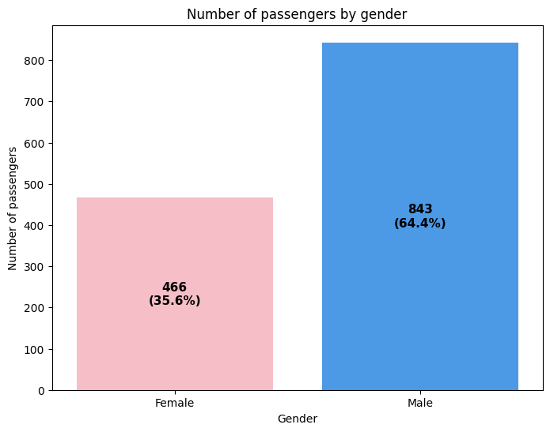

```python
# 1. Distribution of passenger gender

df['sex_label'] = df['sex'].map({'female': 'Female', 'male': 'Male'})

plt.figure(figsize=(8, 6))
ax = sns.countplot(
    x='sex_label',
    hue='sex_label',
    data=df,
    palette=['LightPink', '#3399FF'],
    legend=False
)

plt.title("Number of passengers by gender")
plt.xlabel("Gender")
plt.ylabel("Number of passengers")

# Adding counts and percentages on the bars
total = len(df)
for p in ax.patches:
    count = int(p.get_height())
    pct = 100 * count / total
    ax.text(
        p.get_x() + p.get_width() / 2,
        p.get_height() / 2,
        f'{count}\n({pct:.1f}%)',
        ha='center',
        va='center',
        fontsize=11,
        fontweight='bold'
    )

plt.show()
```

##### The vast majority of passengers were men, who constituted the dominant group in the analyzed sample.

##### Women accounted for only about one third of the total number of passengers, indicating a significant gender imbalance in the distribution.

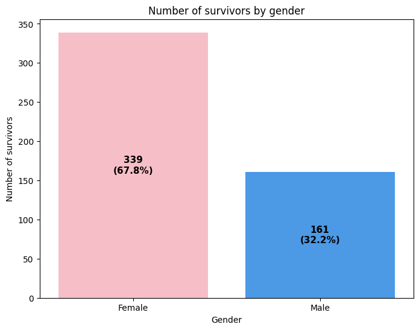

```python
# Number of survivors by gender

# Map gender labels to English
df['sex_label'] = df['sex'].map({'female': 'Female', 'male': 'Male'})

# Filter only survivors
survived_df = df[df['survived'] == 1]
total_survived = len(survived_df)

plt.figure(figsize=(8, 6))
ax = sns.countplot(
    x='sex_label',
    hue='sex_label',
    data=survived_df,
    palette=['LightPink', '#3399FF'],
    legend=False
)

plt.title("Number of survivors by gender")
plt.xlabel("Gender")
plt.ylabel("Number of survivors")

# Add counts and percentages inside the bars
for p in ax.patches:
    count = int(p.get_height())
    pct = 100 * count / total_survived
    ax.text(
        p.get_x() + p.get_width() / 2,
        p.get_height() / 2,
        f'{count}\n({pct:.1f}%)',
        ha='center',
        va='center',
        fontsize=11,
        fontweight='bold'
    )

plt.show()
```

##### The data analysis clearly shows that although men constituted the majority of passengers on board the Titanic, women overwhelmingly dominated among those who survived the disaster.

##### This most likely results from the evacuation rules in place at the time — in life-threatening situations, women and children were given priority when boarding the lifeboats.

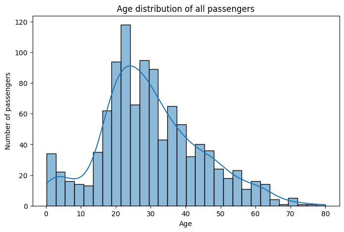

```python
# Checking the impact of age

# Age distribution of all passengers
plt.figure(figsize=(8, 5))
sns.histplot(
    data=df,
    x='age',
    bins=30,
    kde=True
)

plt.title("Age distribution of all passengers")
plt.xlabel("Age")
plt.ylabel("Number of passengers")
plt.show()

total = len(df)
```

```python
df['age'].median()
```

```
28.0
```

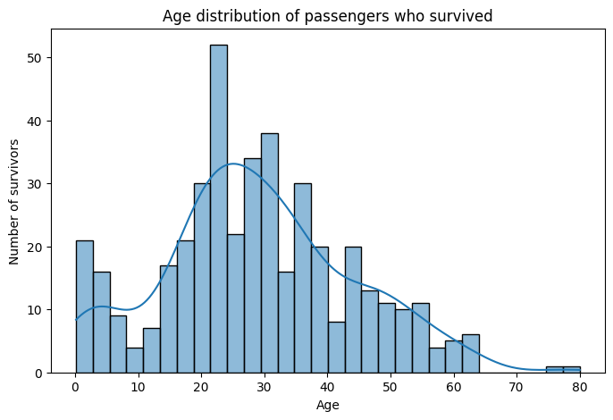

```python
# Age of passengers who survived
plt.figure(figsize=(8, 5))
sns.histplot(
    data=df[df['survived'] == 1],
    x='age',
    bins=30,
    kde=True
)

plt.title("Age distribution of passengers who survived")
plt.xlabel("Age")
plt.ylabel("Number of survivors")
plt.show()
```

```python
df[df['survived'] == 1]['age'].median()
```

```
28.0
```

[figure not shown]

```python
# Survival depending on age
plt.figure(figsize=(8, 5))
sns.histplot(
    data=df,
    x='age',
    hue='survived',
    multiple='stack',
    bins=30,
    palette='Set2'
)

plt.title("Passenger survival by age")
plt.xlabel("Age")
plt.ylabel("Number of passengers")

plt.legend(title='Survived', labels=['No', 'Yes'])
plt.show()
```

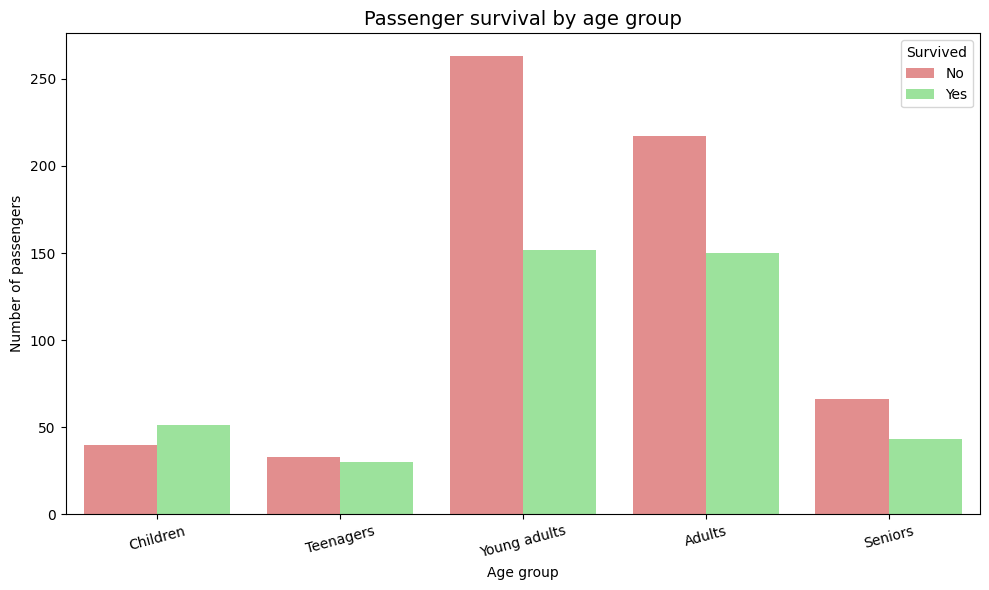

```python
# 🔹 Create age categories
bins = [0, 12, 18, 30, 50, 80]
labels = ['Children', 'Teenagers', 'Young adults', 'Adults', 'Seniors']
df['age_group'] = pd.cut(df['age'], bins=bins, labels=labels, right=False)

# 🔹 Plot
plt.figure(figsize=(10, 6))
ax = sns.countplot(
    data=df,
    x='age_group',
    hue='survived',
    palette=['lightcoral', 'lightgreen']
)

# 🔹 Formatting
plt.title("Passenger survival by age group", fontsize=14)
plt.xlabel("Age group")
plt.ylabel("Number of passengers")
plt.legend(title="Survived", labels=['No', 'Yes'])
plt.xticks(rotation=15)
plt.tight_layout()

plt.show()
```

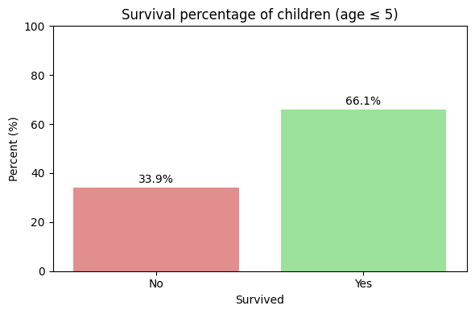

```python
# 1. Filter data: children (age ≤ 5)
children = df[df['age'] <= 5]

# 2. Group by 'survived' and count number of children
count_by_survived = children.groupby('survived').size()

# 3. Calculate percentages
percent_by_survived = (count_by_survived / count_by_survived.sum()) * 100

# 4. Create DataFrame for plotting
result_df = pd.DataFrame({
    'Survived': ['No', 'Yes'],
    'Count': count_by_survived.values,
    'Percent': percent_by_survived.values
})

# 5. Bar plot
plt.figure(figsize=(6, 4))
sns.barplot(data=result_df, x='Survived', y='Percent',hue='Survived', palette=['lightcoral', 'lightgreen'])
plt.title('Survival percentage of children (age ≤ 5)')
plt.ylabel('Percent (%)')
plt.xlabel('Survived')
plt.ylim(0, 100)

# 6. Add value labels above bars
for index, row in result_df.iterrows():
    plt.text(index, row['Percent'] + 2, f"{row['Percent']:.1f}%",
             ha='center', fontsize=10)

plt.tight_layout()
plt.show()
```

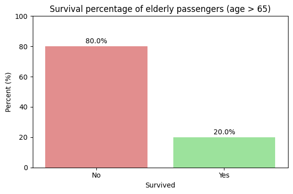

```python
# 1. Filter data: elderly people (age > 65)
elderly = df[df['age'] > 65]

# 2. Group by 'survived' and count number of elderly
count_by_survived_elderly = elderly.groupby('survived').size()

# 3. Calculate percentages
percent_by_survived_elderly = (count_by_survived_elderly / count_by_survived_elderly.sum()) * 100

# 4. Create DataFrame for plotting
elderly_result_df = pd.DataFrame({
    'Survived': ['No', 'Yes'],
    'Count': count_by_survived_elderly.values,
    'Percent': percent_by_survived_elderly.values
})

# 5. Bar plot
plt.figure(figsize=(6, 4))
sns.barplot(
    data=elderly_result_df,
    x='Survived',
    y='Percent',
    hue='Survived',
    palette=['lightcoral', 'lightgreen'],
    dodge=False,
    legend=False     # Hide duplicate legend
)

plt.title('Survival percentage of elderly passengers (age > 65)')
plt.ylabel('Percent (%)')
plt.xlabel('Survived')
plt.ylim(0, 100)

# 6. Add value labels above bars
for index, row in elderly_result_df.iterrows():
    plt.text(index, row['Percent'] + 2, f"{row['Percent']:.1f}%",
             ha='center', fontsize=10)

plt.tight_layout()
plt.show()
```

```python
children = df[df['age'] <= 5]
elderly = df[df['age'] > 65]

# Calculate the percentage of children who survived (survived == 1)
children_survived = children['survived'].mean() * 100

# Calculate the percentage of elderly passengers who survived (survived == 1)
elderly_survived = elderly['survived'].mean() * 100

# Display the results
print(f"Percentage of children who survived: {children_survived:.2f}%")
print(f"Percentage of elderly passengers who survived (>65 years): {elderly_survived:.2f}%")
```

```
Percentage of children who survived: 66.07%
Percentage of elderly passengers who survived (>65 years): 20.00%
```

##### Analysis of the relationship: Survival vs Age

##### 1. Most passengers were between 20 and 40 years old

- The largest number of passengers was in the 20–40 age range.
- This is also the group where the greatest variation between survival and non-survival is visible, indicating significant differences in survival chances within this range.

##### 3. Young adults (20–30 years old) were the largest group of victims

- In the 20–30 age group, there are relatively many victims – orange bars are high.

##### Possible reasons:

- many of them traveled in lower classes (harder access to lifeboats),
- men (especially young men) were given lower priority in the evacuation.

##### 4. Passengers over 50 years old survived less often

- In older age groups (over 50), the number of passengers generally decreases, but the ratio of survivors to non-survivors also worsens.
- This suggests that older passengers may have had difficulty evacuating or were less mobile.

##### 5. Age was an important factor in survival

- There is a clear difference in survival rates between different age groups, indicating that age played an important role in survival chances.
- This relationship is not linear – the youngest had the highest chances, then it declines, and among the elderly survival decreases again.

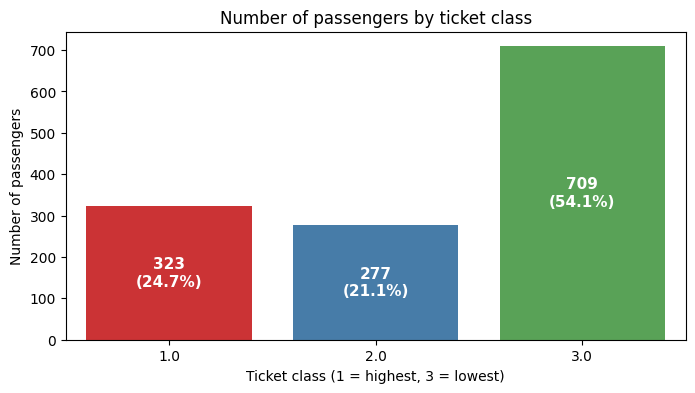

```python
# Ticket class
plt.figure(figsize=(8, 4))
ax = sns.countplot(
    x='pclass',
    data=df,
    hue='pclass',
    palette='Set1',
    dodge=False,
    legend=False
)

plt.title("Number of passengers by ticket class")
plt.xlabel("Ticket class (1 = highest, 3 = lowest)")
plt.ylabel("Number of passengers")

# Calculate number of passengers in each class
counts = df['pclass'].value_counts().sort_index()
total = len(df)

# Add labels on the bars
for i, count in enumerate(counts):
    percent = count / total * 100
    ax.text(
        i, count / 2,           # text position at half the bar height
        f"{count}\n({percent:.1f}%)",
        ha='center', va='center', color='white', fontsize=11, fontweight='bold'
    )

plt.show()
```

- Most passengers traveled in 3rd class
- 3rd class (lowest) had 709 passengers, which accounts for 54.1% of all travelers.
- This means that over half of the passengers were in the lowest class — it was the most crowded and popular section, probably due to lower prices.
- There were significantly fewer passengers in 1st and 2nd class
- 1st class (highest) had 323 passengers (24.7%),
- 2nd class had 277 passengers (21.1%).
- In total, passengers in 1st and 2nd class made up 45.9% of all travelers.

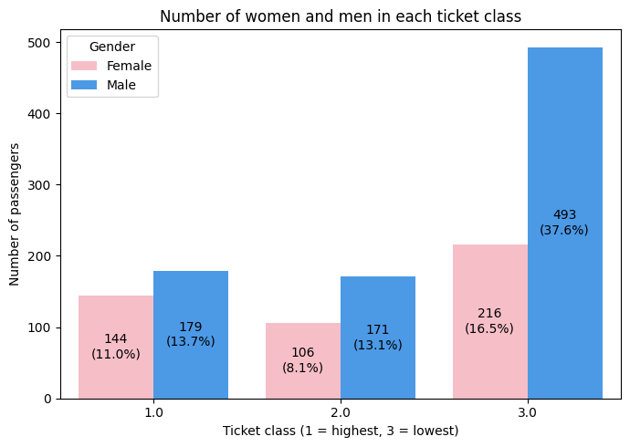

```python
# Number of women and men in each ticket class
plt.figure(figsize=(7, 5))
ax = sns.countplot(
    data=df,
    x='pclass',
    hue='sex',           # differentiate by gender
    palette=['LightPink', '#3399FF'],
    dodge=True            # keep bars side by side
)

plt.title("Number of women and men in each ticket class")
plt.xlabel("Ticket class (1 = highest, 3 = lowest)")
plt.ylabel("Number of passengers")
plt.legend(title='Gender', labels=['Female', 'Male'])
plt.tight_layout()

# Add count and percentage inside each bar
total = len(df)

for patch in ax.patches:
    height = patch.get_height()
    x = patch.get_x() + patch.get_width() / 2

    if height == 0:
        continue  # skip bars with zero height

    percent = height / total * 100
    label = f"{int(height)}\n({percent:.1f}%)"

    # Place the label inside the bar (middle)
    ax.text(x, height / 2, label, ha='center', va='center', fontsize=10, color='black')

plt.show()
```

##### Analysis: Number of women and men in each ticket class

##### 1. Most passengers were in 3rd class

- Both women (216; 16.5%) and men (493; 37.6%) were most numerous in 3rd class.
- 3rd class was by far the most crowded and also heavily male-dominated.
- This is consistent with the earlier conclusion that 3rd class passengers made up over half of all travelers.

##### 2. In every class, men outnumbered women

##### Differences in the number of men and women were visible in all classes:

- 1st class: 179 men vs 144 women
- 2nd class: 171 men vs 106 women
- 3rd class: 493 men vs 216 women

##### This means that men were more numerous in every class group.

##### 3. The largest gender disparity was in 3rd class

- In 3rd class, there were more than twice as many men as women.
- This suggests that many single men (e.g., workers, emigrants) traveled in 3rd class, which may affect further analyses regarding survival.

##### 4. Gender distribution was more balanced in 1st class

- In 1st class, the difference between the number of women and men was relatively the smallest.
- This may indicate that passengers in this class traveled more often in pairs or families.

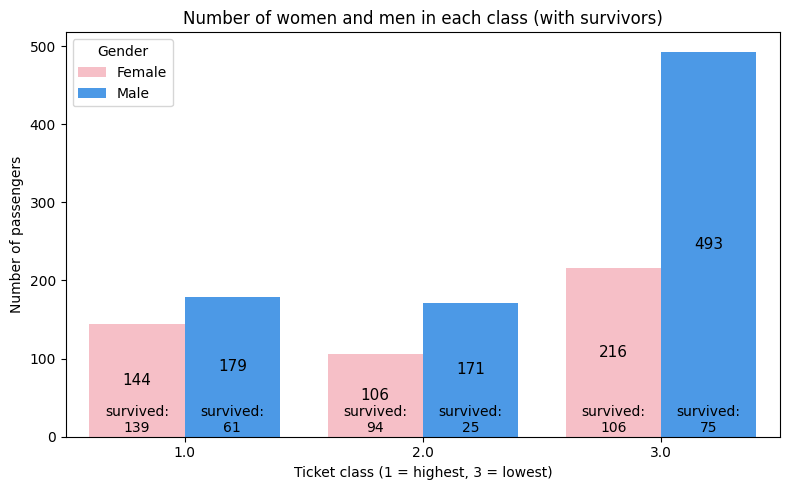

```python
# Number of women and men in each class + number of survivors
plt.figure(figsize=(8, 5))
ax = sns.countplot(
    data=df,
    x='pclass',
    hue='sex',
    palette=['LightPink', '#3399FF'],  # Female = pink, Male = blue
    dodge=True  # bars side by side
)

plt.title("Number of women and men in each class (with survivors)")
plt.xlabel("Ticket class (1 = highest, 3 = lowest)")
plt.ylabel("Number of passengers")
plt.legend(title='Gender', labels=['Female', 'Male'])
plt.tight_layout()

# Total number of passengers in each group (pclass, sex)
counts = df.groupby(['pclass', 'sex']).size().reset_index(name='total_count')

# Number of survivors in each group
survived_counts = df[df['survived'] == 1].groupby(['pclass', 'sex']).size().reset_index(name='survived_count')

# Merge into a single table
merged = pd.merge(counts, survived_counts, on=['pclass', 'sex'], how='left').fillna(0)

# Add labels — total inside bar, survivors above the bar
for container, sex in zip(ax.containers, df['sex'].unique()):
    for rect, pclass in zip(container, sorted(df['pclass'].unique())):
        row = merged[(merged['pclass'] == pclass) & (merged['sex'] == sex)]
        if not row.empty:

            total_n = int(row['total_count'].iloc[0])
            survived_n = int(row['survived_count'].iloc[0])

            # 🔹 Total number — inside the bar
            ax.text(
                rect.get_x() + rect.get_width()/2,
                rect.get_height()/2,
                f"{total_n}",
                ha='center', va='center', fontsize=11, color='black'
            )

            # 🔹 Number of survivors — near bottom of bar
            ax.text(
                rect.get_x() + rect.get_width()/2,
                2,  # small distance from bar base
                f"survived:\n{survived_n}",
                ha='center', va='bottom',
                fontsize=10, color='black'
            )

plt.show()
```

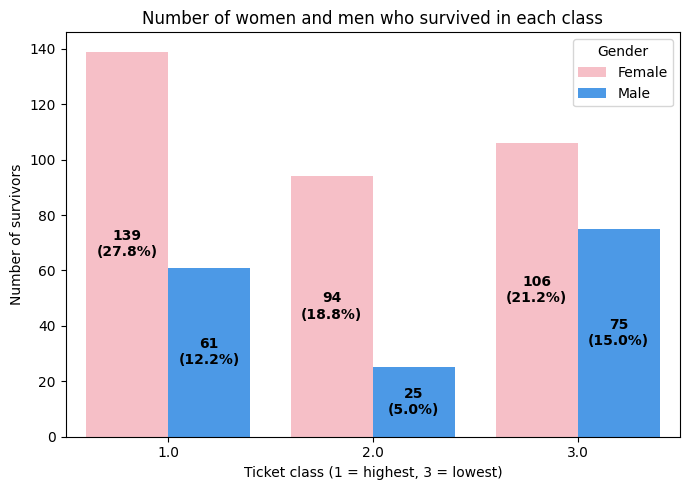

```python
# Filter only passengers who survived
df_survived = df[df['survived'] == 1]

plt.figure(figsize=(7, 5))
ax = sns.countplot(
    data=df_survived,
    x='pclass',
    hue='sex',
    palette=['LightPink', '#3399FF']  # Female = pink, Male = blue
)

plt.title("Number of women and men who survived in each class")
plt.xlabel("Ticket class (1 = highest, 3 = lowest)")
plt.ylabel("Number of survivors")
plt.legend(title='Gender', labels=['Female', 'Male'])
plt.tight_layout()

# Add count and percentage inside each bar
total_survived = len(df_survived)

for patch in ax.patches:
    height = patch.get_height()
    if height == 0:
        continue

    x = patch.get_x() + patch.get_width() / 2
    percent = height / total_survived * 100

    ax.text(
        x,
        height / 2,               # center of the bar
        f'{int(height)}\n({percent:.1f}%)',
        ha='center', va='center',
        fontsize=10, fontweight='bold',
        color='black'
    )

plt.show()
```

### Impact of Ticket Class on Survival Chances

**1st Class (highest ticket class):**

- There are 144 women in this class, of whom 139 survived.
- There are 179 men in this class, of whom only 61 survived.
- This means the survival rate among women in 1st class is much higher (~97%), while among men it is about 34%.

**2nd Class:**

- In 2nd class, there are 106 women, of whom 94 survived.
- There are 171 men, of whom only 25 survived.
- Survival rates in this class are also significantly higher for women (89%) than for men (15%).

**3rd Class (lowest ticket class):**

- In 3rd class, there are 216 women, of whom 106 survived.
- Among men, there are 493, of whom only 75 survived.
- Survival rates are higher among women (49%), while for men they are only about 15%.

**Summary:**

- Women had significantly higher chances of survival across all ticket classes.
- In 1st class, 97% of women survived, dramatically higher than 34% of men.
- In 3rd class, even though the number of male passengers was higher, their survival rate was very low (15%), while women had a higher survival proportion (49%).
- The findings indicate that women had significantly better survival chances compared to men, regardless of ticket class.

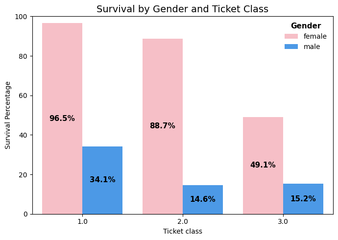

```python
# Survival by gender and ticket class
# Prepare data: calculate survival percentages by gender and class
df_grouped = df.groupby(['pclass', 'sex'])['survived'].mean().reset_index()
df_grouped['survived'] = df_grouped['survived'] * 100  # convert to percentages

# Plotting
plt.figure(figsize=(7, 5))

# Create barplot with Seaborn
ax = sns.barplot(
    x='pclass',
    y='survived',
    hue='sex',
    data=df_grouped,
    palette=['LightPink', '#3399FF']
)

# Set title, labels, and limits
plt.title("Survival by Gender and Ticket Class", fontsize=14)
plt.xlabel("Ticket class")
plt.ylabel("Survival Percentage")
plt.ylim(0, 100)

# Add percentage labels inside the bars
for container in ax.containers:
    ax.bar_label(
        container,
        labels=[f'{h.get_height():.1f}%' for h in container],
        label_type='center',
        color='black',
        fontsize=11,
        fontweight='bold'
    )

# Legend with black text
leg = plt.legend(title='Gender', frameon=False)
plt.setp(leg.get_texts(), color='black', fontsize=10)
plt.setp(leg.get_title(), color='black', fontsize=11, fontweight='bold')

# Adjust layout
plt.tight_layout()
plt.show()
```

##### The chart shows the survival percentage of passengers depending on gender and ticket class. Here are the conclusions, focusing on the impact of class on survival:

##### 1st Class (highest ticket class):

- High survival percentage for both women (96.5%) and men (34.1%).
- Women had a very high chance of survival in this class, almost 97%, while men had much lower chances, only about 34%.

##### 2nd Class:

- Survival percentage is also high among women (88.7%) but much lower among men (14.6%).
- In this class, women still had a very high chance of survival, nearly 89%, while men had only about 15% chance.

##### 3rd Class (lowest ticket class):

- Women in this class had a 49.1% chance of survival, while men only 15.2%.
- Although the survival percentage of women in 3rd class is much lower than in higher classes, it was still significantly higher than that of men (15.2%).

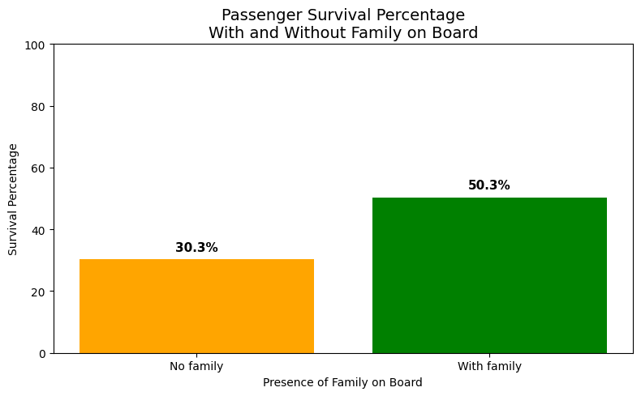

```python
# Step 1: Define who had family on board
df['has_family'] = (df['sibsp'] + df['parch'] > 0).astype(int)

# Step 2: Calculate survival percentage
survival_rates = df.groupby('has_family')['survived'].agg(['mean', 'count']).reset_index()
survival_rates['mean'] *= 100  # convert to percentage

# Replace 0/1 with descriptive labels
survival_rates['has_family'] = survival_rates['has_family'].map({0: 'No family', 1: 'With family'})

plt.figure(figsize=(8, 5))

# Define colors for each bar manually to avoid FutureWarning
colors = ['orange', 'green']  # No family = pink, With family = blue

# Draw bars manually
bars = plt.bar(
    x=survival_rates['has_family'],
    height=survival_rates['mean'],
    color=colors
)

# Labels
plt.title("Passenger Survival Percentage\nWith and Without Family on Board", fontsize=14)
plt.ylabel("Survival Percentage")
plt.xlabel("Presence of Family on Board")
plt.ylim(0, 100)

# Add percentage labels on top of bars
for bar, pct in zip(bars, survival_rates['mean']):
    plt.text(
        bar.get_x() + bar.get_width() / 2,
        bar.get_height() + 2,  # slightly above the bar
        f"{pct:.1f}%",
        ha='center',
        va='bottom',
        fontsize=11,
        fontweight='bold',
        color='black'
    )

plt.tight_layout()
plt.show()
```

- As we can see, passengers traveling with family had a higher survival rate than those traveling alone.
- The presence of women or children in the group may have increased the chances of getting to a lifeboat earlier.
- Additionally, support from family members could have helped passengers react faster and evacuate more effectively.

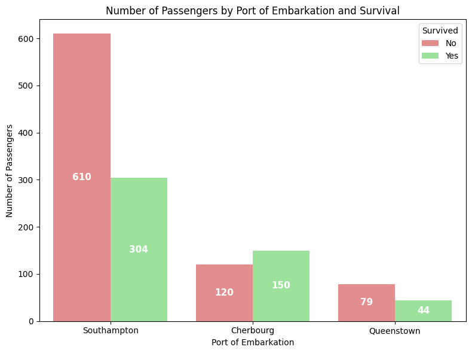

```python
# Survival depending on the port of embarkation
port_labels = {'S': 'Southampton', 'C': 'Cherbourg', 'Q': 'Queenstown'}
df['embarked'] = df['embarked'].map(port_labels)

# Remove missing data
df_plot = df.dropna(subset=['embarked', 'survived'])

plt.figure(figsize=(8, 6))

# Colors: did not survive = red, survived = green
colors = ['lightcoral', 'lightgreen']

ax = sns.countplot(
    data=df_plot,
    x='embarked',
    hue='survived',
    palette=colors
)

# Titles and labels
plt.title("Number of Passengers by Port of Embarkation and Survival")
plt.xlabel("Port of Embarkation")
plt.ylabel("Number of Passengers")
ax.legend(title='Survived', labels=['No', 'Yes'])

# 🔹 Add ONLY counts inside bars (no percentages)
for rect in ax.patches:
    height = rect.get_height()
    if height == 0:
        continue

    x = rect.get_x() + rect.get_width() / 2

    ax.text(
        x,
        height / 2,
        f'{int(height)}',
        ha='center',
        va='center',
        fontsize=11,
        fontweight='bold',
        color='white'
    )

plt.tight_layout()
plt.show()
```

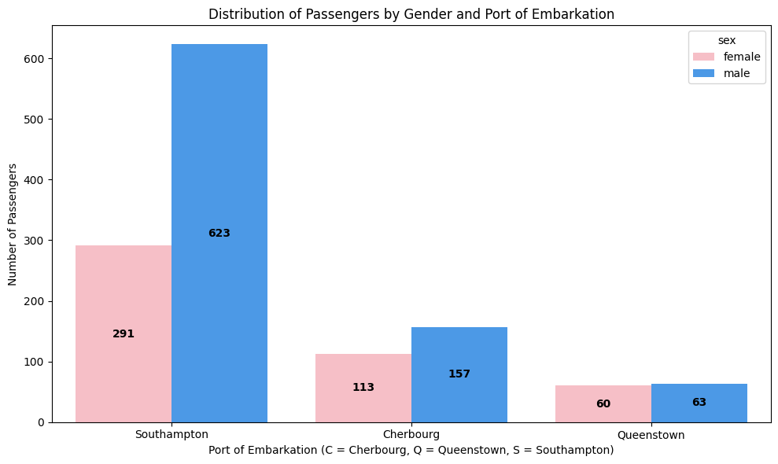

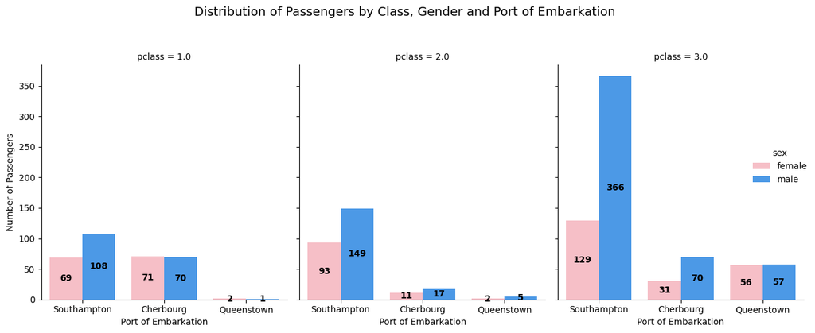

```python
# Plot: distribution of passengers by class and gender for each port of embarkation

plt.figure(figsize=(10, 6))

ax = sns.countplot(
    data=df,
    x='embarked',
    hue='sex',
    palette=['LightPink', '#3399FF'],
    dodge=True
)

# Add counts inside bars
for patch in ax.patches:
    height = patch.get_height()
    if height == 0:
        continue

    x = patch.get_x() + patch.get_width() / 2

    ax.text(
        x,
        height / 2,
        f'{int(height)}',
        ha='center',
        va='center',
        fontsize=10,
        fontweight='bold',
        color='black'
    )

plt.title("Distribution of Passengers by Gender and Port of Embarkation")
plt.xlabel("Port of Embarkation (C = Cherbourg, Q = Queenstown, S = Southampton)")
plt.ylabel("Number of Passengers")
plt.tight_layout()
plt.show()


g = sns.catplot(
    data=df,
    x='embarked',
    hue='sex',
    col='pclass',
    kind='count',
    palette=['LightPink', '#3399FF'],
    height=5,
    aspect=0.8
)

# Add counts to each subplot
for ax in g.axes.flatten():
    for patch in ax.patches:
        height = patch.get_height()
        if height == 0:
            continue

        x = patch.get_x() + patch.get_width() / 2

        ax.text(
            x,
            height / 2,
            f'{int(height)}',
            ha='center',
            va='center',
            fontsize=10,
            fontweight='bold',
            color='black'
        )

g.fig.suptitle(
    "Distribution of Passengers by Class, Gender and Port of Embarkation",
    fontsize=14,
    y=1.05
)

g.set_axis_labels(
    "Port of Embarkation",
    "Number of Passengers"
)

plt.tight_layout()
plt.show()
```

#### Analysis: Survival Rate by Port of Embarkation (Embarked)

##### The first chart shows how many passengers from each port (Southampton, Cherbourg, Queenstown) survived the disaster.

- The largest number of passengers boarded in Southampton, but they also had the lowest survival rate (approx. 33%).
- Passengers from Cherbourg had the highest survival rate (approx. 55%), despite being a much smaller group.
- Passengers from Queenstown had a survival rate similar to Southampton (approx. 36%).

##### Overall Conclusion:

The port of embarkation did not have a direct impact on survival — it was only an indirect indicator of passengers’ social status and ticket class. These two factors (along with gender) played the most critical role in determining survival.

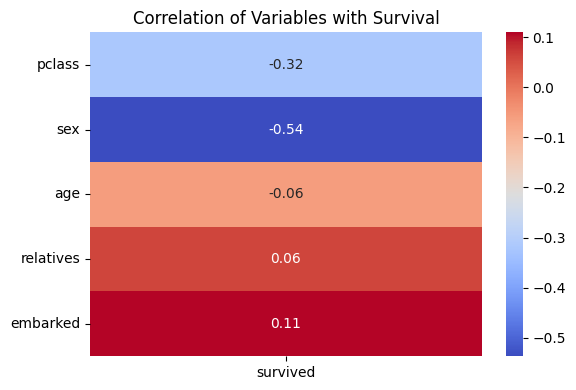

```python
# Correlation of Variables with Survival

# 1. Create a new column – total number of relatives
df['relatives'] = df['sibsp'] + df['parch']

# 2. Select variables for correlation
df_corr = df[['survived', 'pclass', 'sex', 'age', 'relatives', 'embarked']].copy()

# Encode sex
df_corr['sex'] = df_corr['sex'].map({'male': 1, 'female': 0})

# Encode embarked (handles full names)
df_corr['embarked'] = df_corr['embarked'].map({
    'Southampton': 0,
    'Cherbourg': 1,
    'Queenstown': 2
})

# 3. Remove rows with missing values
df_corr = df_corr.dropna()

# 4. Compute correlation matrix
corr_matrix = df_corr.corr()

# 5. Extract correlations with 'survived'
corr_with_survived = corr_matrix[['survived']].drop('survived')

# 6. Plot heatmap
plt.figure(figsize=(6, 4))
sns.heatmap(
    corr_with_survived,
    annot=True,
    cmap='coolwarm',
    fmt=".2f",
    cbar=True
)

plt.title("Correlation of Variables with Survival")
plt.tight_layout()
plt.show()
```

##### The chart shows the correlation of various variables with survival ("survived"). The conclusions are as follows:

##### Gender (sex):

- The correlation is -0.54, which indicates a strong negative correlation with survival. Women had significantly higher chances of survival than men.

##### Ticket class (pclass):

- The correlation is -0.32, indicating a moderate negative correlation with survival. Passengers in 1st class had higher chances of survival, while those in 3rd class had lower chances.

##### Age (age):

- The correlation is -0.06, suggesting a very weak correlation. Age does not have a strong impact on survival, although younger passengers may have had slightly higher chances of survival.

##### Number of relatives (relatives):

- The correlation is 0.06, indicating a very weak, almost negligible correlation. The number of relatives a passenger had did not significantly affect their survival chances.

##### Port of embarkation (embarked):

- The correlation is 0.11, indicating a very weak positive correlation. Passengers who embarked at certain ports may have had slightly higher chances of survival, but the effect of this variable is marginal.

##### Summary:

- The strongest factor influencing survival was gender, with women having much higher survival rates.
- Ticket class also had a noticeable impact—passengers traveling in 1st class were more likely to survive.
- Age, number of relatives, and port of embarkation had minimal impact on survival.

# 4. Final Conclusions

##### The most important factors influencing survival:

- **Gender** — one of the strongest factors.
- Women had significantly higher chances of survival than men, which confirms the evacuation rule: *“women and children first.”*
- **Ticket class (social status)** — first-class passengers had substantially higher chances of survival than those traveling in second and third class.
- **Age** — children, especially those from higher classes, had slightly higher survival chances than adult men.
- Among elderly passengers, survival rates were lower, particularly in the lower classes.

##### The most affected group:

- **Third-class men**, especially those who boarded in Southampton or Queenstown.

Survival in the Titanic disaster depended heavily on a passenger’s gender and social class.  
It was not random, but rather a reflection of the social inequalities and rules in force at the time.

The analysis shows that privileged groups (wealthier passengers and women) had the greatest chances of survival, while men from lower classes constituted the majority of the victims.